# Introduction to R Programming

### 1.3.2 Creating a function

We write functions to help us to write code in easy to understand chunks. Also, it helps to write reusable code avoid repetitive code lines. A functional function must have certain parameters: A function `name` which is the assigned to the function `function()`, `inputs` or arguments supplied inside the brackets (function(x,y,z)), the curly brackets `{}` to enclose the instructions to be performed, `instructions` to performed supplied inside the curly brackets, then finally the `return()` to output the result of the last instruction performed. Below is a general structure of a function.

functionname <- function(inputs){

output_value <- do_something(input)

return(output_value)

}

The curly brackets indicate that the instructions inside them are a group hence must be processed together.

```r
#Function to calculate the volume of a box
    # inputs: length=23, width= 20, height=10

boxvolume <- function(length, width, height){
  area_of_crosssection <- length*height
  volume <- area_of_crosssection * width
  return(volume)
}

#calling the function
boxvolume(23, 20,10)
```

```
## [1] 4600
```

```r
#store the results for use later
bvolume <- boxvolume(23, 20,10)
```

### 1.3.3 For Loops

For Loops are used for repeating things in R. They are fundamental structures for performing repetitions in programming. They work by performing the same actions for each item in a list of items like a vector. The key word is `for` which means for each item in the list of items supplied. Basic structure looks like this:

for(item in vector_of_items){

do_something(item)

}

You need to first create a vector of items to loop over. There are two variants of the For loops. By value and by index.

#### 1.3.3.1 For Loops by value

For loop by value uses the value of a vector to loop over and over until all the elements of the vector have been processed.

```r
#A For Loop to calculate masses from each volume of the box

volumes <- c(1.6, 3, 8, 9)
for(vol in volumes){
  mass <- 2.65*volumes^0.95
  print(mass)
} #not sure why four rows are created
```

```
## [1]  4.141521  7.525079 19.106510 21.368609
## [1]  4.141521  7.525079 19.106510 21.368609
## [1]  4.141521  7.525079 19.106510 21.368609
## [1]  4.141521  7.525079 19.106510 21.368609
```

#### 1.3.3.2 For Loops by index

For loops by index loops over a vector using the index of each element typically starting at 1. The integers (indices) are used to access the values we need from one or more vectors at the position indicated by the index.

```r
volumes <- c(1.6, 3, 8, 9)

for(i in 1:length(volumes)){
  mass <- 2.65*volumes[i]^0.95
  print(mass)
}
```

```
## [1] 4.141521
## [1] 7.525079
## [1] 19.10651
## [1] 21.36861
```

Looping by index helps in storing the results of the loop for use later unlike looping by values. To store the values of the loop, create an empty object of the same length as the vector of items.

```r
volumes <- c(1.6, 3, 8, 9)
masses <- vector(length=length(volumes), mode="numeric") #vector function creates an empty vector with argument length, mode option changes the type of vector

for(i in 1:length(volumes)){
  mass <- 2.65*volumes[i]^0.95
  masses[i] <- mass #stores the outputs as it loops
}

masses
```

```
## [1]  4.141521  7.525079 19.106510 21.368609
```

Looping by index also allows users to loop over multiple objects at the same time. For example if you want to change the constant 2.65 and exponent 0.95 depending on the circumstance

```r
volumes <- c(1.6, 3, 8, 9)
cons <- c(2.65, 3.4, 6.1, 4.3)
expo <- c(0.95, 1.1, 1.5, 2.5)

masses <- vector(length=length(volumes), mode="numeric") #vector function creates an empty vector with argument length, mode option changes the type of vector

for(i in 1:length(volumes)){
  mass <- cons[i]*volumes[i]^expo[i]
  masses[i] <- mass #stores the outputs as it loops
}

masses
```

```
## [1]    4.141521   11.384456  138.027244 1044.900000
```

#### 1.3.3.3 Looping over files

The code below is commented out as there are no files yet in the training folder directory.

```r
#data_files <- list.files(pattern="") #get list of files you want
#results <- vector(length=length(data_files), mode="integer") #create an empty vector of length equal to number of files

#for(i in 1:length(data_files)){
#  data <- read.csv(data_file[i]) #read the csv file (if they are csv files)
#  count <- nrow(data) #count observations if this is what your want
#  results[1] <- count #store the counts for each data files
#}
```

### 1.3.4 While Loops

While loops allows you to the code to repeat while a condition is true and stops when the condition is no longer true.

```r
#What will be the amount at the end of a year after monthly deposit of 1000 and interest rate of 8% on monthly balance

Whileloop <- function(){

  acc <- c(0)
  Month = 1

  while (Month<=12){

    acc <- (acc*1.08)+1000 #replace the first vector after each calculation
    print(acc)

    Month <- Month + 1 #replace the counter with the next increment
    #print(counter)
  }
}

Whileloop()
```

```
## [1] 1000
## [1] 2080
## [1] 3246.4
## [1] 4506.112
## [1] 5866.601
## [1] 7335.929
## [1] 8922.803
## [1] 10636.63
## [1] 12487.56
## [1] 14486.56
## [1] 16645.49
## [1] 18977.13
```

```r
#Above is similar to For loop but no need of adding the iterator
Forloop <- function(){

  acc=0

  for (Month in 1:12){
    acc <- (acc * 1.08) +1000

    print(acc)
    #print(Month)
  }

}

Forloop()
```

```
## [1] 1000
## [1] 2080
## [1] 3246.4
## [1] 4506.112
## [1] 5866.601
## [1] 7335.929
## [1] 8922.803
## [1] 10636.63
## [1] 12487.56
## [1] 14486.56
## [1] 16645.49
## [1] 18977.13
```

```r
#How do I get just the last value?
```

### 1.3.5 Looping Using the if Statements

You can combine loops and functions by putting most of the codes we want to run in a function the calling one more functions each time through the loop. As an example we can use a non-vectorised function to estimate the mass. This type of loop uses the `if` and `else` functions.

If statements allows users to write functions that outputs a result if a condition is true.

```r
#Example 1 : Combined if statement and For Loop

est_mass <- function(volume){
  if (volume>5){
    mass <- 2.65*volume^0.95
  } else {
    mass <- NA
  }
  return(mass)
}

volumes <- c(1.6,3,8,4,9)
masses <- vector(length=length(volumes), mode="numeric")

for(i in 1:length(volumes)){
  mass <- est_mass(volumes[i])
  masses[i] <- mass
}

masses
```

```
## [1]       NA       NA 19.10651       NA 21.36861
```

```r
(mass_sapply <- sapply(volumes, est_mass)) # this code is similar to the above for loop
```

```
## [1]       NA       NA 19.10651       NA 21.36861
```

```r
#Example 2
#Test what to wear depending on  temperature of the day.

Hoodie <- function(temperature){

  if (temperature <25){
    print("Wear hoodie")
  }
  else if (temperature == 25){
    print("Wear vest")
  }
  else {
    print("Wear nothing")
  }
}

Hoodie(26)
```

```
## [1] "Wear nothing"
```

## 1.4 R Packages

R provides a wide range of packages that enable users to perform specific tasks efficiently in R environment. An R package is a collection of functions and can be downloaded from CRAN (Comprehensive R Archive Network). CRAN is the repository for R packages. Some packages already exist in the R environment but some of them must be installed first before they can used. Some packages exists together in an ecosystem of packages for specific tasks. For example the tydyverse package is an ecosystem of packages that enable users clean data, produce graphs and charts, transform data, import data and handle dates

### 1.4.1 Installing and loading a package

Installing an R package is very simple. The function `install.packages("packagename")`is used. This makes the package available for access to RStudio but cannot be used yet. One has to load the package into R environment to be able use it and this is done using the function `library(packagename)`. Some packages can exist in more than one ecosystem and one might wish to explicitly indicate the ecosystem from which the package is from by using using double colons as `ecosystemname::packagename`. One has to have an internet connection to be able install packages. The pacman function can be handy in loading packages at once. `if(!require(pacman))install.packages("pacman") pacman::p_load(insertpackageshere)`

Below are examples of packages commonly used.

`install.packages("magrittr")`

`install.packages("table1")`

`install.packages("arsenal")`

`install.packages("tinytex")`

`install.packages("readxl")`

`install.packages("haven")`

`install.packages("gmodels")`

```r
#library(tidyverse) #en ecosystem (collection) of packages like the dplyr,ggplot2, lubridate, tidyr, tibble, stringr, readr, for data cleaning, manipulation, transformation, visualization

#library(magrittr)   # package for piping i.e %>% piping is handy when you want to avoid nesting of functions.

#library(table1) #for descriptive data analysis in HTML

#library(arsenal) #for running proc compare on two datasets and other complex tasks

#library(tinytex) #contains functions for compiling LaTex documents

#library(readxl) #for importing xls dataset

#library(haven) #for importing and exporting SPSS, STATA and SAS files

#library(gmodels) #package for model fitting

#library(knitr) #package for dynamic reporting in R
```

## 1.5 Data Wrangling

Data wrangling includes a series of processes that involves tidying data that ends up with suitable datasets for analysis. This starts from reading in data from where it’s stored and having a clean data after all the processes. The tidyverse ecosystem of packages has packages of functions that support data wrangling. Package for reading in data `readr`, for generating visuals `ggplot2`, for tidying data `tidyr`, for formatting dates `lubridate`, for modifying a data frame for efficient reading `tibble` and for transforming data `dplyr`. These packages have functions inside them that support what they are intended for.

### 1.5.1 Setting work directory

You need to know your working directory before reading in data into the R environment. To know the current working directory use the function `getwd()`. If the directory is different from where you need to save your work, you need to change/set your work directory using the function `setwd()` copy the path to where you want to save work the paste in the setwd() function all wrapped in `""`. Change the backslashes `\` to forward slashes `/` in the path directory.

Use `dir()` to view the files in the directory.

```r
#Knowing your directory
getwd()
```

```
## [1] "C:/Users/Dwayne/OneDrive/R/Projects/RTraining"
```

```r
dir() #get list of files in the
```

```
##  [1] "CleanData"        "CleaningSTData.R" "LearningR.html"   "LearningR.pdf"
##  [5] "LearningR.Rmd"    "LearningR_files"  "LICENSE"          "RawData"
##  [9] "README.md"        "RTraining.Rproj"
```

```r
#You can save the list of the files in a R object in case you would want to access any of the items in the list.

(file <-dir())
```

```
##  [1] "CleanData"        "CleaningSTData.R" "LearningR.html"   "LearningR.pdf"
##  [5] "LearningR.Rmd"    "LearningR_files"  "LICENSE"          "RawData"
##  [9] "README.md"        "RTraining.Rproj"
```

```r
list.files() #this is an alternative to dir()
```

```
##  [1] "CleanData"        "CleaningSTData.R" "LearningR.html"   "LearningR.pdf"
##  [5] "LearningR.Rmd"    "LearningR_files"  "LICENSE"          "RawData"
##  [9] "README.md"        "RTraining.Rproj"
```

### 1.5.2 Reading and writing datasets

The readr package of the tidyverse has functions that enables R users to read and write/save files of different formats.

`CSV files` are text files that have data/values separated by commas. The `read.csv(csvfilename)` functions from readr reads in the csv file and converts it to a data frame for use in R. The `write.csv` function saves he csv file into the working directory. Run `?read.csv` or `?write.csv` to check for the options allowed for these functions.

`Excel` files can include `xls` or `xlsx`. These are files with data arranged in rows and columns. R has the package `readxl` that allows users to read in these files. Use the function `read_excel(excelname)` to read the files. `read_xls()` and `read_xlsx()` also exists for reading excel files. Run `?read_excel` to learn about the options that the function can take.

```r
#(df <- read_excel("Dataset/STIData.xls")) #practice data for this training
#View(df) #you can view the data to see all the variables and observations.
#R will always rename variables that have similar names as has happened with the sex variable.
```

`Text` files are files with values separated by various characters; comma, space, pipe, or semi colon. The `read.table()` function is inbuilt R for reading such files. I requires no package installation. The function takes a number of options. The function is similar to read.csv in reading in csv files however, one has to specify the value separator. Run `?read_table` to learn about the options that the function can take.

```r
#(df <- read.table("Dataset/filename.txt", ""))
```

R also support reading data from other soft ware eg `SAS, STATA or SPSS` files. The package `haven` has a number of functions has allows one to reading in file formats from other software.

You can also read in html tables, tables on web pages. The function `readHTMLTable()` allows you to download a webpage table and analyse.

To connect to databases to read tables directly from a database, one needs the function `dbConnect(dbname(), user="username", password="password", dbname="databasename", host="hos")`

### 1.5.3 Exploring data

Before working with your data you need to understand the data. This entails knowing number of your variables and their characteristics, the dimensions of the data, number of observations and the structure of your data. The tidyverse package has packages and functions that helps you explore and clean data.

Exploring the `starwars`, a dataset accessed from R. The `starwars` data is a good one to explore.

Below are some of the functions you can use to explore your data.

```r
library(tidyverse) #first loading the package you will need
#library(readxl)  #load the package for reading the kind of the format
#(df <- read_excel("Dataset/STIData.xls")) #read in your data

(df <- starwars)
```

```
## # A tibble: 87 × 14
##    name     height  mass hair_color skin_color eye_color birth_year sex   gender
##    <chr>     <int> <dbl> <chr>      <chr>      <chr>          <dbl> <chr> <chr>
##  1 Luke Sk…    172    77 blond      fair       blue            19   male  mascu…
##  2 C-3PO       167    75 <NA>       gold       yellow         112   none  mascu…
##  3 R2-D2        96    32 <NA>       white, bl… red             33   none  mascu…
##  4 Darth V…    202   136 none       white      yellow          41.9 male  mascu…
##  5 Leia Or…    150    49 brown      light      brown           19   fema… femin…
##  6 Owen La…    178   120 brown, gr… light      blue            52   male  mascu…
##  7 Beru Wh…    165    75 brown      light      blue            47   fema… femin…
##  8 R5-D4        97    32 <NA>       white, red red             NA   none  mascu…
##  9 Biggs D…    183    84 black      light      brown           24   male  mascu…
## 10 Obi-Wan…    182    77 auburn, w… fair       blue-gray       57   male  mascu…
## # ℹ 77 more rows
## # ℹ 5 more variables: homeworld <chr>, species <chr>, films <list>,
## #   vehicles <list>, starships <list>
```

```r
glimpse(df)
```

```
## Rows: 87
## Columns: 14
## $ name       <chr> "Luke Skywalker", "C-3PO", "R2-D2", "Darth Vader", "Leia Or…
## $ height     <int> 172, 167, 96, 202, 150, 178, 165, 97, 183, 182, 188, 180, 2…
## $ mass       <dbl> 77.0, 75.0, 32.0, 136.0, 49.0, 120.0, 75.0, 32.0, 84.0, 77.…
## $ hair_color <chr> "blond", NA, NA, "none", "brown", "brown, grey", "brown", N…
## $ skin_color <chr> "fair", "gold", "white, blue", "white", "light", "light", "…
## $ eye_color  <chr> "blue", "yellow", "red", "yellow", "brown", "blue", "blue",…
## $ birth_year <dbl> 19.0, 112.0, 33.0, 41.9, 19.0, 52.0, 47.0, NA, 24.0, 57.0, …
## $ sex        <chr> "male", "none", "none", "male", "female", "male", "female",…
## $ gender     <chr> "masculine", "masculine", "masculine", "masculine", "femini…
## $ homeworld  <chr> "Tatooine", "Tatooine", "Naboo", "Tatooine", "Alderaan", "T…
## $ species    <chr> "Human", "Droid", "Droid", "Human", "Human", "Human", "Huma…
## $ films      <list> <"The Empire Strikes Back", "Revenge of the Sith", "Return…
## $ vehicles   <list> <"Snowspeeder", "Imperial Speeder Bike">, <>, <>, <>, "Imp…
## $ starships  <list> <"X-wing", "Imperial shuttle">, <>, <>, "TIE Advanced x1",…
```

```r
#View(df) #view your data
dim(df) #knowing the dimensions of your data, number of observations and variables
```

```
## [1] 87 14
```

```r
#str(df) #displays the structure of the data
#attach(df) #avoid the need of attaching the name of dataset to varnames
#detach(df)
head(df) #have a glimbse of the first 6 variables
```

```
## # A tibble: 6 × 14
##   name      height  mass hair_color skin_color eye_color birth_year sex   gender
##   <chr>      <int> <dbl> <chr>      <chr>      <chr>          <dbl> <chr> <chr>
## 1 Luke Sky…    172    77 blond      fair       blue            19   male  mascu…
## 2 C-3PO        167    75 <NA>       gold       yellow         112   none  mascu…
## 3 R2-D2         96    32 <NA>       white, bl… red             33   none  mascu…
## 4 Darth Va…    202   136 none       white      yellow          41.9 male  mascu…
## 5 Leia Org…    150    49 brown      light      brown           19   fema… femin…
## 6 Owen Lars    178   120 brown, gr… light      blue            52   male  mascu…
## # ℹ 5 more variables: homeworld <chr>, species <chr>, films <list>,
## #   vehicles <list>, starships <list>
```

```r
tail(df) #have a glimbse of the last 6 variables
```

```
## # A tibble: 6 × 14
##   name      height  mass hair_color skin_color eye_color birth_year sex   gender
##   <chr>      <int> <dbl> <chr>      <chr>      <chr>          <dbl> <chr> <chr>
## 1 Finn          NA    NA black      dark       dark              NA male  mascu…
## 2 Rey           NA    NA brown      light      hazel             NA fema… femin…
## 3 Poe Dame…     NA    NA brown      light      brown             NA male  mascu…
## 4 BB8           NA    NA none       none       black             NA none  mascu…
## 5 Captain …     NA    NA unknown    unknown    unknown           NA <NA>  <NA>
## 6 Padmé Am…    165    45 brown      light      brown             46 fema… femin…
## # ℹ 5 more variables: homeworld <chr>, species <chr>, films <list>,
## #   vehicles <list>, starships <list>
```

```r
names(df) #lists variable names
```

```
##  [1] "name"       "height"     "mass"       "hair_color" "skin_color"
##  [6] "eye_color"  "birth_year" "sex"        "gender"     "homeworld"
## [11] "species"    "films"      "vehicles"   "starships"
```

```r
length(df) #variables in the dataset
```

```
## [1] 14
```

```r
length(df$species) #total observations in the variable
```

```
## [1] 87
```

```r
class(df$species) #types of variable
```

```
## [1] "character"
```

```r
unique(df$sex) #unique entries in the variable
```

```
## [1] "male"           "none"           "female"         "hermaphroditic"
## [5] NA
```

```r
table(df$height) #table summary of variable, but doesn't count missing values
```

```
##
##  66  79  88  94  96  97 112 122 137 150 157 160 163 165 166 167 168 170 171 172
##   1   1   1   1   2   1   1   1   1   2   1   1   2   3   1   2   1   4   1   1
## 173 175 177 178 180 182 183 184 185 188 190 191 193 196 198 200 202 206 213 216
##   1   3   1   4   5   1   7   1   1   5   1   3   3   3   2   1   1   2   1   1
## 224 228 229 234 264
##   1   1   1   1   1
```

```r
#View(sort(table(df$height), decreasing=TRUE)) #wrapping functions
summary(df$mass) #measure of spread
```

```
##    Min. 1st Qu.  Median    Mean 3rd Qu.    Max.    NA's
##   15.00   55.60   79.00   97.31   84.50 1358.00      28
```

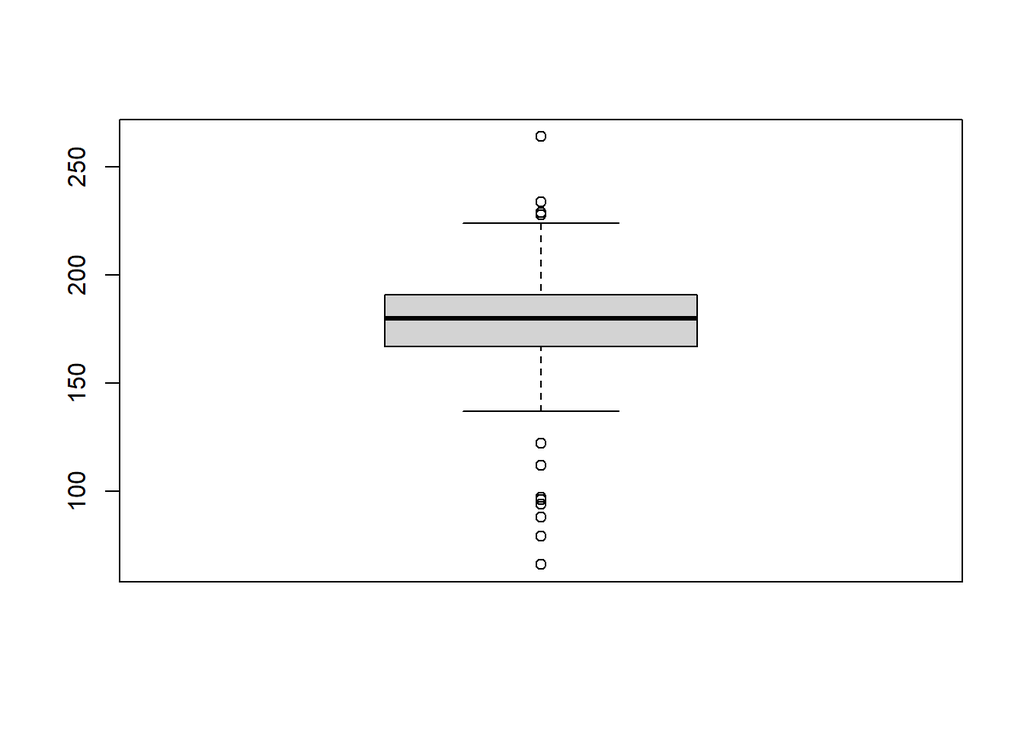

```r
boxplot(df$height) #gives a quick view of distribution, box and whiskers
```

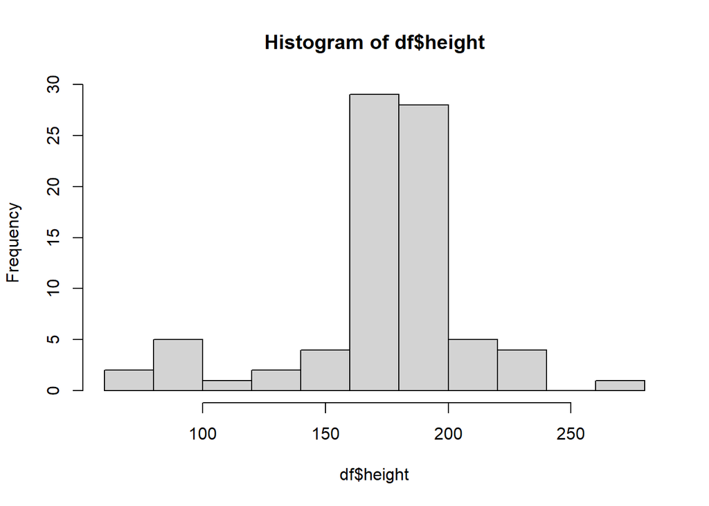

```r
hist(df$height) #view distribution of any numeric variable, good data should be normally distributed
```

### 1.5.4 Cleaning data

```r
(df <- starwars)
```

```
## # A tibble: 87 × 14
##    name     height  mass hair_color skin_color eye_color birth_year sex   gender
##    <chr>     <int> <dbl> <chr>      <chr>      <chr>          <dbl> <chr> <chr>
##  1 Luke Sk…    172    77 blond      fair       blue            19   male  mascu…
##  2 C-3PO       167    75 <NA>       gold       yellow         112   none  mascu…
##  3 R2-D2        96    32 <NA>       white, bl… red             33   none  mascu…
##  4 Darth V…    202   136 none       white      yellow          41.9 male  mascu…
##  5 Leia Or…    150    49 brown      light      brown           19   fema… femin…
##  6 Owen La…    178   120 brown, gr… light      blue            52   male  mascu…
##  7 Beru Wh…    165    75 brown      light      blue            47   fema… femin…
##  8 R5-D4        97    32 <NA>       white, red red             NA   none  mascu…
##  9 Biggs D…    183    84 black      light      brown           24   male  mascu…
## 10 Obi-Wan…    182    77 auburn, w… fair       blue-gray       57   male  mascu…
## # ℹ 77 more rows
## # ℹ 5 more variables: homeworld <chr>, species <chr>, films <list>,
## #   vehicles <list>, starships <list>
```

```r
df %>% mutate(weight = df$mass*10) # create a new variable from an existing one
```

```
## # A tibble: 87 × 15
##    name     height  mass hair_color skin_color eye_color birth_year sex   gender
##    <chr>     <int> <dbl> <chr>      <chr>      <chr>          <dbl> <chr> <chr>
##  1 Luke Sk…    172    77 blond      fair       blue            19   male  mascu…
##  2 C-3PO       167    75 <NA>       gold       yellow         112   none  mascu…
##  3 R2-D2        96    32 <NA>       white, bl… red             33   none  mascu…
##  4 Darth V…    202   136 none       white      yellow          41.9 male  mascu…
##  5 Leia Or…    150    49 brown      light      brown           19   fema… femin…
##  6 Owen La…    178   120 brown, gr… light      blue            52   male  mascu…
##  7 Beru Wh…    165    75 brown      light      blue            47   fema… femin…
##  8 R5-D4        97    32 <NA>       white, red red             NA   none  mascu…
##  9 Biggs D…    183    84 black      light      brown           24   male  mascu…
## 10 Obi-Wan…    182    77 auburn, w… fair       blue-gray       57   male  mascu…
## # ℹ 77 more rows
## # ℹ 6 more variables: homeworld <chr>, species <chr>, films <list>,
## #   vehicles <list>, starships <list>, weight <dbl>
```

```r
df %>%  select(1:5) #selecting variables in position 1 to 5
```

```
## # A tibble: 87 × 5
##    name               height  mass hair_color    skin_color
##    <chr>               <int> <dbl> <chr>         <chr>
##  1 Luke Skywalker        172    77 blond         fair
##  2 C-3PO                 167    75 <NA>          gold
##  3 R2-D2                  96    32 <NA>          white, blue
##  4 Darth Vader           202   136 none          white
##  5 Leia Organa           150    49 brown         light
##  6 Owen Lars             178   120 brown, grey   light
##  7 Beru Whitesun lars    165    75 brown         light
##  8 R5-D4                  97    32 <NA>          white, red
##  9 Biggs Darklighter     183    84 black         light
## 10 Obi-Wan Kenobi        182    77 auburn, white fair
## # ℹ 77 more rows
```

```r
(misshair <- df %>%
             filter(is.na(df$hair_color)))# Selecting rows with hair colour missing
```

```
## # A tibble: 5 × 14
##   name      height  mass hair_color skin_color eye_color birth_year sex   gender
##   <chr>      <int> <dbl> <chr>      <chr>      <chr>          <dbl> <chr> <chr>
## 1 C-3PO        167    75 <NA>       gold       yellow           112 none  mascu…
## 2 R2-D2         96    32 <NA>       white, bl… red               33 none  mascu…
## 3 R5-D4         97    32 <NA>       white, red red               NA none  mascu…
## 4 Greedo       173    74 <NA>       green      black             44 male  mascu…
## 5 Jabba De…    175  1358 <NA>       green-tan… orange           600 herm… mascu…
## # ℹ 5 more variables: homeworld <chr>, species <chr>, films <list>,
## #   vehicles <list>, starships <list>
```

```r
#Selecting rows then only 3 rows then sorting from largest to smallest

(flt <- df %>%
        filter(hair_color == "brown")%>%
        select(name, height, hair_color)%>%
        arrange (-height) %>%
        glimpse())
```

```
## Rows: 18
## Columns: 3
## $ name       <chr> "Tarfful", "Chewbacca", "Qui-Gon Jinn", "Raymus Antilles", …
## $ height     <int> 234, 228, 193, 188, 183, 183, 180, 180, 170, 165, 165, 165,…
## $ hair_color <chr> "brown", "brown", "brown", "brown", "brown", "brown", "brow…
```

```
## # A tibble: 18 × 3
##    name                  height hair_color
##    <chr>                  <int> <chr>
##  1 Tarfful                  234 brown
##  2 Chewbacca                228 brown
##  3 Qui-Gon Jinn             193 brown
##  4 Raymus Antilles          188 brown
##  5 Ric Olié                 183 brown
##  6 Cliegg Lars              183 brown
##  7 Han Solo                 180 brown
##  8 Jek Tono Porkins         180 brown
##  9 Wedge Antilles           170 brown
## 10 Beru Whitesun lars       165 brown
## 11 Dormé                    165 brown
## 12 Padmé Amidala            165 brown
## 13 Cordé                    157 brown
## 14 Leia Organa              150 brown
## 15 Wicket Systri Warrick     88 brown
## 16 Arvel Crynyd              NA brown
## 17 Rey                       NA brown
## 18 Poe Dameron               NA brown
```

```r
#recoding observations: not working

(recod<- df %>%
        mutate(sexcodes=df$sex) #%>%
        #recode(sexcodes,"male"=1, "female"=2, "hermaphroditic"=3, "none"=99, "NA"=97)
)
```

```
## # A tibble: 87 × 15
##    name     height  mass hair_color skin_color eye_color birth_year sex   gender
##    <chr>     <int> <dbl> <chr>      <chr>      <chr>          <dbl> <chr> <chr>
##  1 Luke Sk…    172    77 blond      fair       blue            19   male  mascu…
##  2 C-3PO       167    75 <NA>       gold       yellow         112   none  mascu…
##  3 R2-D2        96    32 <NA>       white, bl… red             33   none  mascu…
##  4 Darth V…    202   136 none       white      yellow          41.9 male  mascu…
##  5 Leia Or…    150    49 brown      light      brown           19   fema… femin…
##  6 Owen La…    178   120 brown, gr… light      blue            52   male  mascu…
##  7 Beru Wh…    165    75 brown      light      blue            47   fema… femin…
##  8 R5-D4        97    32 <NA>       white, red red             NA   none  mascu…
##  9 Biggs D…    183    84 black      light      brown           24   male  mascu…
## 10 Obi-Wan…    182    77 auburn, w… fair       blue-gray       57   male  mascu…
## # ℹ 77 more rows
## # ℹ 6 more variables: homeworld <chr>, species <chr>, films <list>,
## #   vehicles <list>, starships <list>, sexcodes <chr>
```

#### 1.5.4.1 Handling Missing data

#### 1.5.4.2 Handling dates and times

#### 1.5.4.3 Handling strings

#### 1.5.4.4 Handling dupicates

#### 1.5.4.5 Handling factor variables

#### 1.5.4.6 Restructuring data

Load gapminder dataset

```r
library(gapminder)
(gapm <- gapminder)
```

```
## # A tibble: 1,704 × 6
##    country     continent  year lifeExp      pop gdpPercap
##    <fct>       <fct>     <int>   <dbl>    <int>     <dbl>
##  1 Afghanistan Asia       1952    28.8  8425333      779.
##  2 Afghanistan Asia       1957    30.3  9240934      821.
##  3 Afghanistan Asia       1962    32.0 10267083      853.
##  4 Afghanistan Asia       1967    34.0 11537966      836.
##  5 Afghanistan Asia       1972    36.1 13079460      740.
##  6 Afghanistan Asia       1977    38.4 14880372      786.
##  7 Afghanistan Asia       1982    39.9 12881816      978.
##  8 Afghanistan Asia       1987    40.8 13867957      852.
##  9 Afghanistan Asia       1992    41.7 16317921      649.
## 10 Afghanistan Asia       1997    41.8 22227415      635.
## # ℹ 1,694 more rows
```

```r
#unique(gapminder$country)
str(gapm)
```

```
## tibble [1,704 × 6] (S3: tbl_df/tbl/data.frame)
##  $ country  : Factor w/ 142 levels "Afghanistan",..: 1 1 1 1 1 1 1 1 1 1 ...
##  $ continent: Factor w/ 5 levels "Africa","Americas",..: 3 3 3 3 3 3 3 3 3 3 ...
##  $ year     : int [1:1704] 1952 1957 1962 1967 1972 1977 1982 1987 1992 1997 ...
##  $ lifeExp  : num [1:1704] 28.8 30.3 32 34 36.1 ...
##  $ pop      : int [1:1704] 8425333 9240934 10267083 11537966 13079460 14880372 12881816 13867957 16317921 22227415 ...
##  $ gdpPercap: num [1:1704] 779 821 853 836 740 ...
```

```r
#View(gapm)

names(gapm)
```

```
## [1] "country"   "continent" "year"      "lifeExp"   "pop"       "gdpPercap"
```

```r
#Select observations from Kenya in the gapminder

(kenya <- gapm %>%
          filter(country=="Kenya") %>%
          select(country,year, lifeExp, pop, gdpPercap) %>%
          arrange(year))
```

```
## # A tibble: 12 × 5
##    country  year lifeExp      pop gdpPercap
##    <fct>   <int>   <dbl>    <int>     <dbl>
##  1 Kenya    1952    42.3  6464046      854.
##  2 Kenya    1957    44.7  7454779      944.
##  3 Kenya    1962    47.9  8678557      897.
##  4 Kenya    1967    50.7 10191512     1057.
##  5 Kenya    1972    53.6 12044785     1222.
##  6 Kenya    1977    56.2 14500404     1268.
##  7 Kenya    1982    58.8 17661452     1348.
##  8 Kenya    1987    59.3 21198082     1362.
##  9 Kenya    1992    59.3 25020539     1342.
## 10 Kenya    1997    54.4 28263827     1360.
## 11 Kenya    2002    51.0 31386842     1288.
## 12 Kenya    2007    54.1 35610177     1463.
```

## 1.6 Exploratory Data Analysis

Exploratory Data Analysis is about understanding your data to know the pattern of data and relationship between variables. This can help suggest modeling strategy or help policy makers make data driven policies. EDA largely look for central tendencies or measures of spread. Types of graphs include box plot,density plot and pie charts.

### 1.6.1 Univariate data analysis

Analysis of single variable.

```r
library(readxl)
xlsxd<-read_xlsx("CleanData/STIData_Cleaned.xlsx")
View(xlsxd)
summary(xlsxd)
```

```
##    IdNumber          CaseStatus             Date
##  Length:227         Length:227         Min.   :2008-12-08 00:00:00.0
##  Class :character   Class :character   1st Qu.:2009-12-04 00:00:00.0
##  Mode  :character   Mode  :character   Median :2009-12-05 00:00:00.0
##                                        Mean   :2009-12-03 02:32:14.7
##                                        3rd Qu.:2009-12-06 00:00:00.0
##                                        Max.   :2009-12-08 00:00:00.0
##
##       Age           AgeCat              Sex             Occupation
##  Min.   :16.00   Length:227         Length:227         Length:227
##  1st Qu.:23.00   Class :character   Class :character   Class :character
##  Median :26.00   Mode  :character   Mode  :character   Mode  :character
##  Mean   :28.04
##  3rd Qu.:32.00
##  Max.   :63.00
##
##     Church          Level_Of_Education Marital_Status         Weight
##  Length:227         Length:227         Length:227         Min.   : 32.80
##  Class :character   Class :character   Class :character   1st Qu.: 45.50
##  Mode  :character   Mode  :character   Mode  :character   Median : 51.00
##                                                           Mean   : 53.75
##                                                           3rd Qu.: 60.75
##                                                           Max.   :100.00
##
##      Height        STI_Yes_No     Burial_Society  Religious_Group
##  Min.   :138.0   Min.   :0.0000   Min.   :1.000   Min.   :1.000
##  1st Qu.:156.0   1st Qu.:0.0000   1st Qu.:1.000   1st Qu.:1.000
##  Median :160.0   Median :0.0000   Median :2.000   Median :1.000
##  Mean   :160.9   Mean   :0.1534   Mean   :1.661   Mean   :1.449
##  3rd Qu.:166.0   3rd Qu.:0.0000   3rd Qu.:2.000   3rd Qu.:2.000
##  Max.   :191.0   Max.   :1.0000   Max.   :2.000   Max.   :2.000
##  NA's   :1       NA's   :64
##   Savings_Club  Traders_Association    Group1             Group2
##  Min.   :1.00   Min.   :1.000       Length:227         Length:227
##  1st Qu.:1.00   1st Qu.:2.000       Class :character   Class :character
##  Median :2.00   Median :2.000       Mode  :character   Mode  :character
##  Mean   :1.73   Mean   :1.947
##  3rd Qu.:2.00   3rd Qu.:2.000
##  Max.   :2.00   Max.   :2.000
##  NA's   :1
```

[output cut: 41 more lines]

```
##  Min.   :1.000   Min.   :1.000   Min.   :0.0000    Min.   :0.00000
##  1st Qu.:2.000   1st Qu.:1.000   1st Qu.:0.0000    1st Qu.:0.00000
##  Median :2.000   Median :2.000   Median :0.0000    Median :0.00000
##  Mean   :1.881   Mean   :1.702   Mean   :0.2291    Mean   :0.09692
##  3rd Qu.:2.000   3rd Qu.:2.000   3rd Qu.:0.0000    3rd Qu.:0.00000
##  Max.   :2.000   Max.   :2.000   Max.   :1.0000    Max.   :1.00000
##                  NA's   :2
##  Last_Partner_Spouse     Belong        ReceiveHelp     SexPartnerLife3
##  Min.   :0.0000      Min.   :0.0000   Min.   :0.0000   Min.   :0.0000
##  1st Qu.:0.0000      1st Qu.:0.0000   1st Qu.:0.0000   1st Qu.:0.0000
##  Median :1.0000      Median :1.0000   Median :1.0000   Median :0.0000
##  Mean   :0.6916      Mean   :0.7004   Mean   :0.6872   Mean   :0.4053
##  3rd Qu.:1.0000      3rd Qu.:1.0000   3rd Qu.:1.0000   3rd Qu.:1.0000
##  Max.   :1.0000      Max.   :1.0000   Max.   :1.0000   Max.   :1.0000
##
```

Looking at numeric variables(some continuous variables) , weight and height

```r
#spread of weight across the population
summary(xlsxd$Weight) #spread of weight across the population
```

```
##    Min. 1st Qu.  Median    Mean 3rd Qu.    Max.
##   32.80   45.50   51.00   53.75   60.75  100.00
```

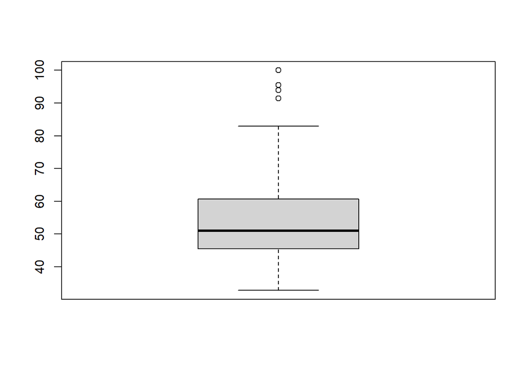

```r
boxplot(xlsxd$Weight)
```

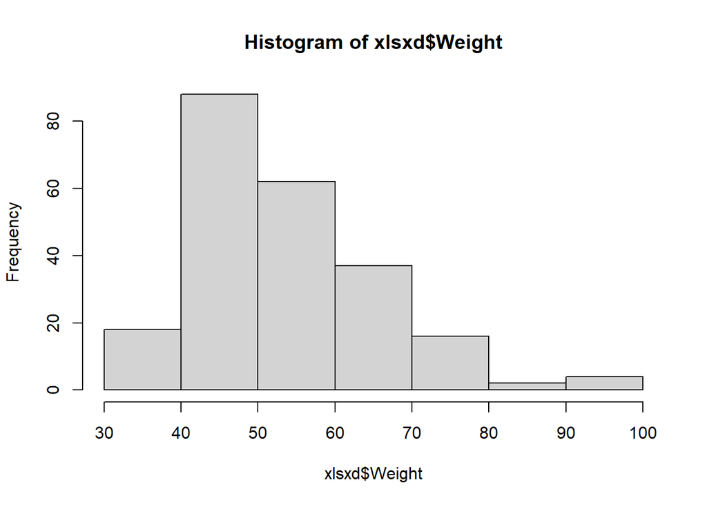

```r
hist(xlsxd$Weight)
```

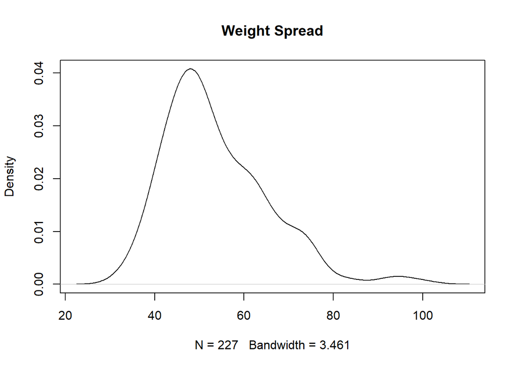

```r
plot(density(xlsxd$Weight), main="Weight Spread")
```

```r
#spread of height across the population
summary(xlsxd$Height) #spread of weight across the population
```

```
##    Min. 1st Qu.  Median    Mean 3rd Qu.    Max.    NA's
##   138.0   156.0   160.0   160.9   166.0   191.0       1
```

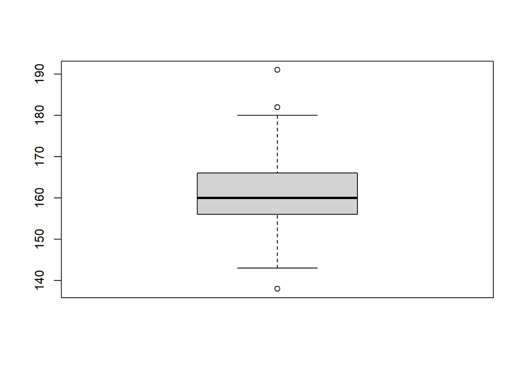

```r
boxplot(xlsxd$Height)
```

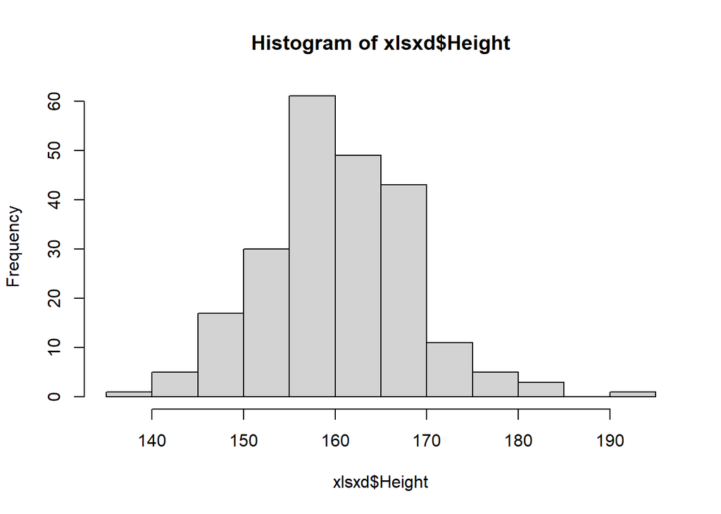

```r
hist(xlsxd$Height)
```

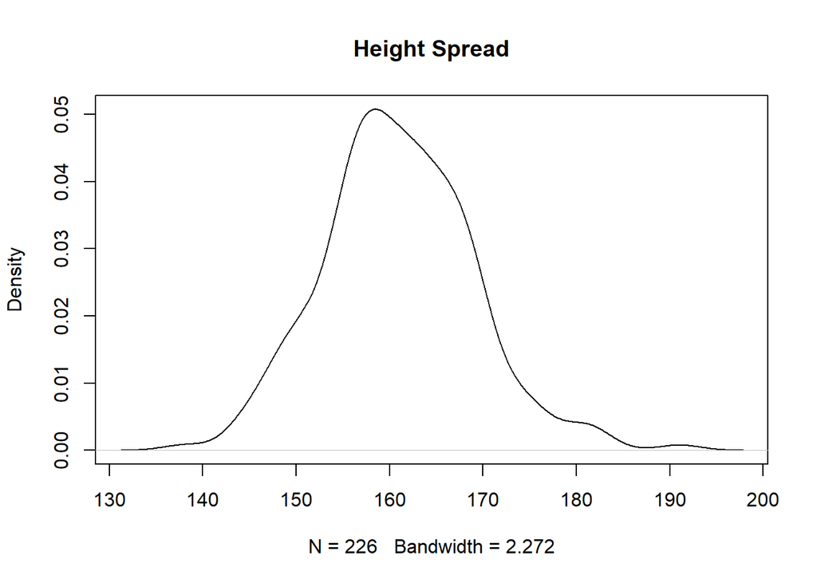

```r
plot(density(xlsxd$Height, na.rm=T),main="Height Spread")
```

```r
#spread of Age across the population
summary(xlsxd$Age) #spread of weight across the population
```

```
##    Min. 1st Qu.  Median    Mean 3rd Qu.    Max.
##   16.00   23.00   26.00   28.04   32.00   63.00
```

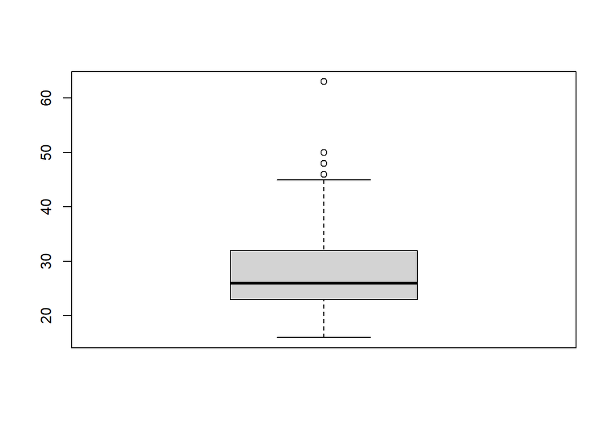

```r
boxplot(xlsxd$Age)
```

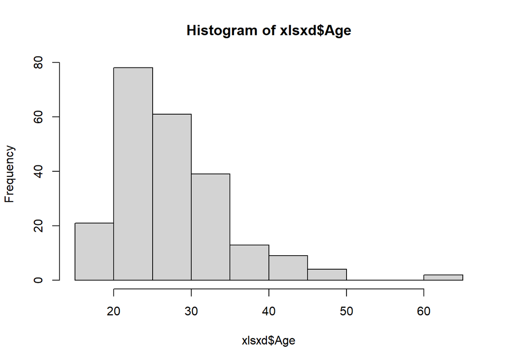

```r
hist(xlsxd$Age)
```

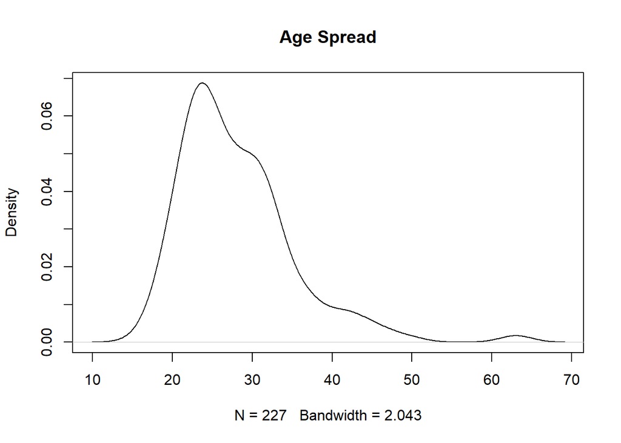

```r
plot(density(xlsxd$Age, na.rm=T),main="Age Spread")
```

```r
# table1::table1(xlsxd$AgeCat)
```

### 1.6.2 Multivariate Data analysis

## 1.7 Data Visualisation

### 1.7.1 Boxplots

### 1.7.2 Piecharts

### 1.7.3 Histograms

### 1.7.4 Barcharts

### 1.7.5 Heat maps

### 1.7.6 Bubble graphs

## 1.8 R Shiny

### 1.8.1 Building and interactive dashboard

### 1.8.2 Developing an RShiny Web App

# 2 ADVANCED PROGRAMMING